# Power Required to Keep vechical at Given Speed

Distribution of Power Based on Vehical and Rolling Coefficient

Ruben Sanchez Ramirez

February 22, 2021

### **Error Checking:**

Working from the previous Assignment 2a, we added some error checking to our function “power_watts.R” This is a way to check for error so that if user gives garbage data, the function does not compute inaccurate power.

- First we wanted to make sure we have the same number of mass_kg and surface_area for each car so that they are matched. This was solved by adding an “if” Statment to the function.
- Then we wanted to make sure that the inputs for mass, surface area, and velocity were not negative. This was solved by adding “ifelse” statments for each variable.

### **Function:**

Use the same function as in Assignment2a:

**Pb = crolling * m * g * V + 1/2 A * pair * cdrag * V3**

where *crolling* and *cdrag* are rolling and aerodynamic resistive coefficients, typical values are 0.015 and 0.3, respectively

*V*: is vehicle speed (assuming no headwind) in m/s (or mps) m: is vehicle mass in kg

*A* is surface area of car (m2)

*g* is acceleration due to gravity (9.8 m/s2) pair = density of air (1.2kg/m3)

*Pb* is power in Watts

### **Effects of Highway Rolling Coefficient:**

We want to compare 4 cars with different masses and different surface areas:

- car A mass 20000 kg, area 22 m<sup>2</sup>
- car B mass 65000 kg, area 30 m<sup>2</sup>
- car C mass 38000 kg, area 22 m<sup>2</sup>
- car D mass 30000 kg, area 10 m<sup>2</sup>

**create a random sample of 100 highways each with a different rolling coefficient** Sample the rolling coefficient from a uniform distribution with a **minimum value of 0.01 and a maximum value of 0.03**, sample 100 different highways.

### **First Use For Loops**

Other programming language (and R) use what are called loops - where repetition is more explicit

```
##    Min. 1st Qu.  Median    Mean 3rd Qu.    Max.
## 0.01052 0.01646 0.02062 0.02067 0.02549 0.02978
```

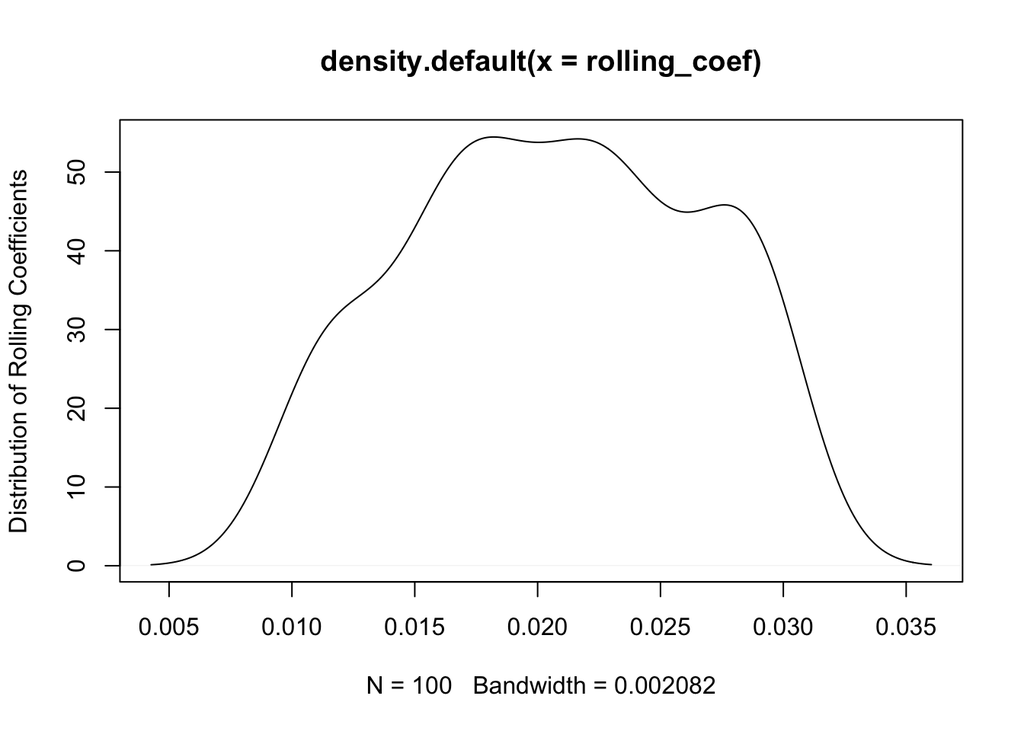

```
##   V1 V2 V3 V4
## 1 NA NA NA NA
## 2 NA NA NA NA
## 3 NA NA NA NA
## 4 NA NA NA NA
## 5 NA NA NA NA
## 6 NA NA NA NA
```

```
## [1] 100
```

```
##         V1       V2       V3       V4
## 1 220770.4 440770.7 287432.1 177785.5
## 2 297369.1 689716.6 432969.7 292683.6
## 3 325623.9 781544.7 486653.8 335065.8
## 4 264240.9 582049.9 370026.0 242991.2
## 5 300072.1 698501.2 438105.3 296738.0
## 6 267083.9 591289.6 375427.7 247255.7
```

```
## # A tibble: 6 x 2
##   car     power
##   <chr>   <dbl>
## 1 A     220770.
## 2 B     440771.
## 3 C     287432.
## 4 D     177785.
## 5 A     297369.
## 6 B     689717.
```

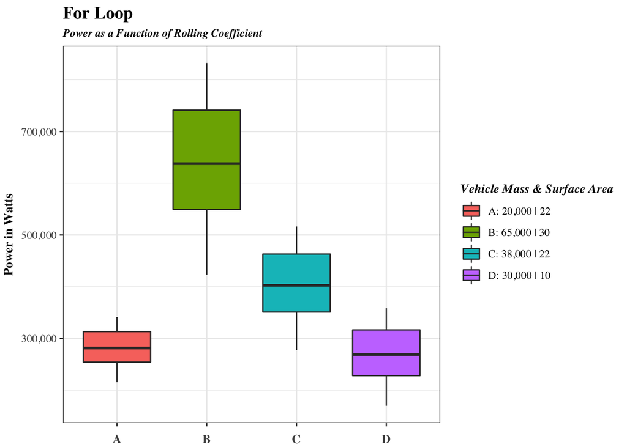

### **Second Using pmap**

*pmap* is available in the *purr* library

*mapply* is another R option

```
##          A        B        C        D
## 1 220770.4 440770.7 287432.1 177785.5
## 2 297369.1 689716.6 432969.7 292683.6
## 3 325623.9 781544.7 486653.8 335065.8
## 4 264240.9 582049.9 370026.0 242991.2
## 5 300072.1 698501.2 438105.3 296738.0
## 6 267083.9 591289.6 375427.7 247255.7
```

```
## # A tibble: 6 x 2
##   car     power
##   <chr>   <dbl>
## 1 A     220770.
## 2 B     440771.
## 3 C     287432.
## 4 D     177785.
## 5 A     297369.
## 6 B     689717.
```

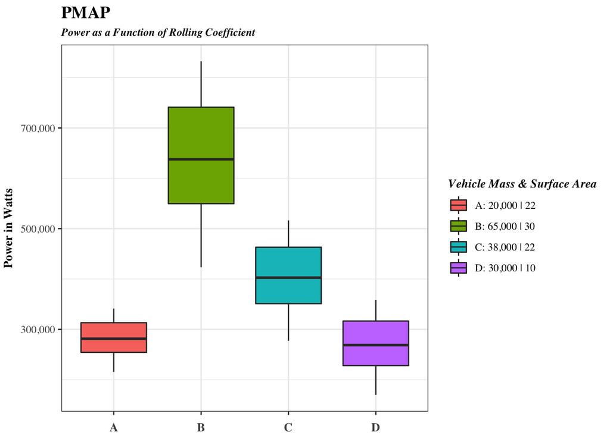

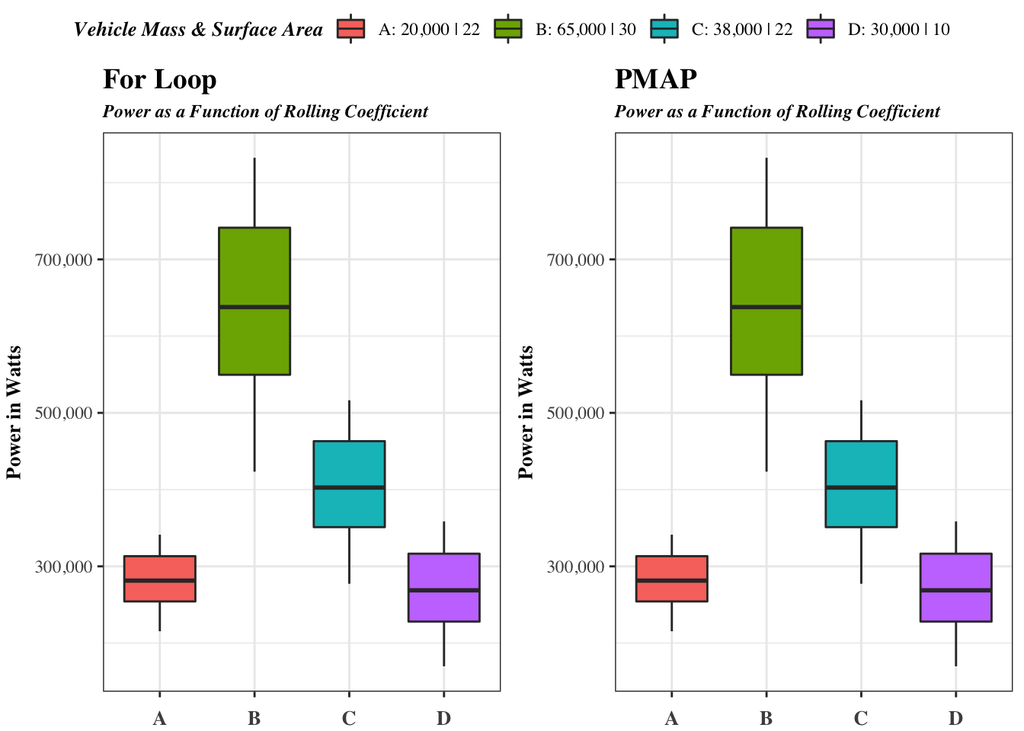

```
##          A        B        C        D
## 1 220770.4 440770.7 287432.1 177785.5
## 2 297369.1 689716.6 432969.7 292683.6
## 3 325623.9 781544.7 486653.8 335065.8
## 4 264240.9 582049.9 370026.0 242991.2
## 5 300072.1 698501.2 438105.3 296738.0
## 6 267083.9 591289.6 375427.7 247255.7
```

```
##          A        B        C        D
## 1 220770.4 440770.7 287432.1 177785.5
## 2 297369.1 689716.6 432969.7 292683.6
## 3 325623.9 781544.7 486653.8 335065.8
## 4 264240.9 582049.9 370026.0 242991.2
## 5 300072.1 698501.2 438105.3 296738.0
## 6 267083.9 591289.6 375427.7 247255.7
```